# Week 8 Assignment

Luis Hernandez Centti

Wednesday, October 22, 2014

# **Intro**

This week 8 assignment abour rmkadown is based on my project 3. This report is based on the airquality package, and then I added a couple of variables to make it a wider data.My goal here was to calculate the real feel sensation of tempertaure, how the weather channels and weather scientific do it, they calculate their reports based on mathematical formulas, we need to create new variable in order to calcualte the real feel sensation. I added the variable Windchill temperature and then the resultant variable RealFeel.

To calculate the Windchill temperature we needed to know the atmospheric temperature and the air speed, both of this we got it from the original aiquality package. Here is the formula how to calculate the windchill:

### **Equation for Windchill:**

T{wc}=13.12 + 0.6215 T_a-11.37 V^{+0.16} + 0.3965 T_a V^{+0.16}

Also we can get accurate and hourly windchill temperature from this graph, by updating the requied values onto the formula.

[figure not shown]

To calcualte the apparent temperature of also called the Real feel temperature we used the following formula:

## **Equation to find the appararent temperature:**

### **Then from we get this information on the airquality data set**

The monthly data set is more accurate because it show only the values with accurate information, filtering out the NAs.

```r
summary(airquality1)
```

```
##      Ozone           Solar.R           Wind             Temp
##  Min.   :  1.00   Min.   :  7.0   Min.   : 1.700   Min.   :56.00
##  1st Qu.: 18.00   1st Qu.:115.8   1st Qu.: 7.400   1st Qu.:72.00
##  Median : 31.50   Median :205.0   Median : 9.700   Median :79.00
##  Mean   : 42.13   Mean   :185.9   Mean   : 9.958   Mean   :77.88
##  3rd Qu.: 63.25   3rd Qu.:258.8   3rd Qu.:11.500   3rd Qu.:85.00
##  Max.   :168.00   Max.   :334.0   Max.   :20.700   Max.   :97.00
##  NA's   :37       NA's   :7
##      Month            Day          RealFeel      WindchillTemp
##  Min.   :5.000   Min.   : 1.0   Min.   : 39.91   Min.   : 52.47
##  1st Qu.:6.000   1st Qu.: 8.0   1st Qu.: 72.44   1st Qu.: 73.56
##  Median :7.000   Median :16.0   Median : 86.76   Median : 81.92
##  Mean   :6.993   Mean   :15.8   Mean   : 90.55   Mean   : 80.47
##  3rd Qu.:8.000   3rd Qu.:23.0   3rd Qu.:107.92   3rd Qu.: 89.38
##  Max.   :9.000   Max.   :31.0   Max.   :148.98   Max.   :104.25
##                                 NA's   :42
```

```r
summary(monthly)
```

```
##       Day            Month          RealFeel
##  Min.   : 1.00   Min.   :5.000   Min.   : 39.91
##  1st Qu.: 9.00   1st Qu.:6.000   1st Qu.: 72.44
##  Median :16.00   Median :7.000   Median : 86.76
##  Mean   :15.95   Mean   :7.216   Mean   : 90.55
##  3rd Qu.:22.50   3rd Qu.:9.000   3rd Qu.:107.92
##  Max.   :31.00   Max.   :9.000   Max.   :148.98
```

### **Then we can started to plot our information:**

First plot for the REal FEel monthly report:

```
## stat_bin: binwidth defaulted to range/30. Use 'binwidth = x' to adjust this.
```

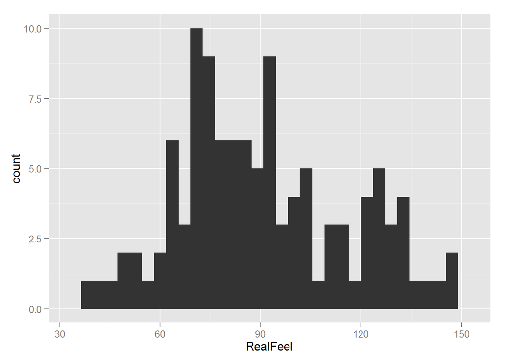

```r
ggplot(airquality1, aes(x=RealFeel)) +
geom_bar(width =.3)
```

### **Heres another way to plot it using barplot**

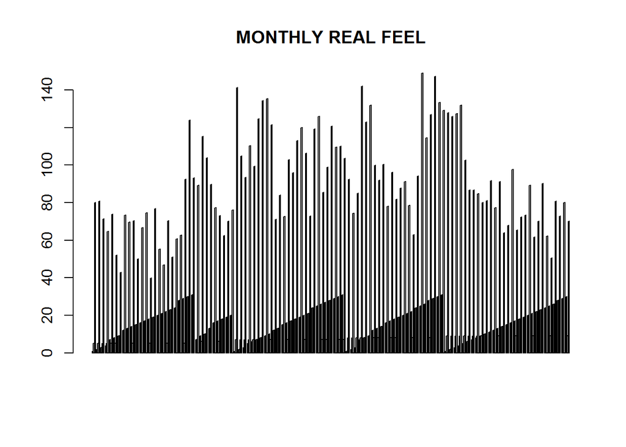

```r
barplot(t(as.matrix(monthly)), main="MONTHLY REAL FEEL",beside=TRUE)
```

## **Observations:**

SOURCES:

To get the wind chill equation http://planetcalc.com/2087/

to get the apparent temperature equation http://planetcalc.com/2089/